# Generalized linear models

14 September 2026

## Basics

## Basics

- in R: `glm()`, model specification as before: `glm(y~f1+x1+f2+x2, data=..., family=..., ...)`
- definition: **family**/**link function**

## Family

- family: what kind of data (response variable) do I have?
  - from **first principles**: family specifies the relationship between the mean and variance
  - `family=binomial`: proportions, out of a total number of counts; includes binary (Bernoulli) (“logistic regression”)
  - `family=poisson`: Poisson (independent counts, no set maximum, or far from the maximum)
  - other (Normal (`"gaussian"`), Gamma)
- default family for `glm` is Gaussian
- most GLMs (93%) are logistic or Poisson

## What is `family` really doing?

- under the hood: specifying the **variance function**, e.g.
  - Gaussian: constant variance
  - Poisson: variance = mean
  - binomial: variance prop to \(p(1-p)\)
- for classic GLMs, this is all you need to fit the model correctly

## Link functions

- on what scale are the relationship(s) between predictor(s) and response linear?
- link function goes from *data* scale (counts, proportions etc.) to *effect* or *link* or *linear predictor* scale
  - Poisson=log; binomial=logit
- *inverse link* function goes from effect scale to data scale
  - Poisson=exponential; binomial=logistic
- each family has a default “canonical” link (sensible + nice math)
  - default is usually fine (*except*: use `family=Gamma(link="log")`)

## Machinery

- “linear predictor” \(\eta = \beta_0 + \beta_1 x_1 + \ldots\) describes patterns on the link scale
- Fit **doesn’t transform the responses**: instead applies *inverse* link function to the linear predictor
  - instead of \(\log(y) \sim x\), we analyze \(y \sim \mathrm{Poisson}(\exp(x))\)
- this is good, because the observed value of \(y\) might be zero
  - e.g. count (Poisson) phenotype vs. temperature (centered at 20°C)
  - with \(\beta=\{1,0.1\}\), \(T=15\):
  - counts \(\sim \textrm{Poisson}(\lambda=\exp(1 + 0.1 \cdot (15-20)))\)
  - = \(\textrm{Poisson}(\lambda = \exp(0.5))=\textrm{Poisson}(\lambda=1.649)\)

## Machinery (2)

Model setup is almost the same as linear models

- categorical vs. continuous predictors
- contrasts
- interactions
- etc.

but the linear relationship is assumed **on the linear predictor (link) scale**

## log/exponential function: count data

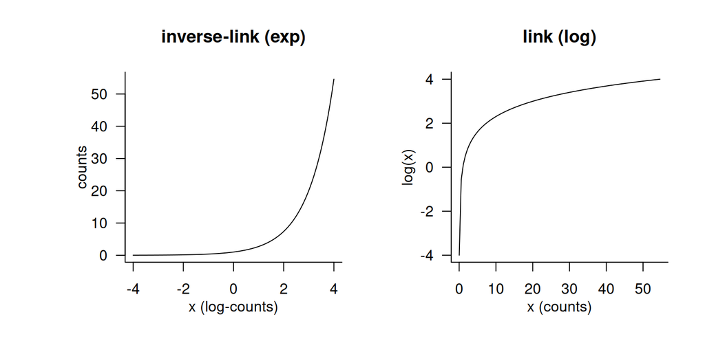

## logit/logistic function

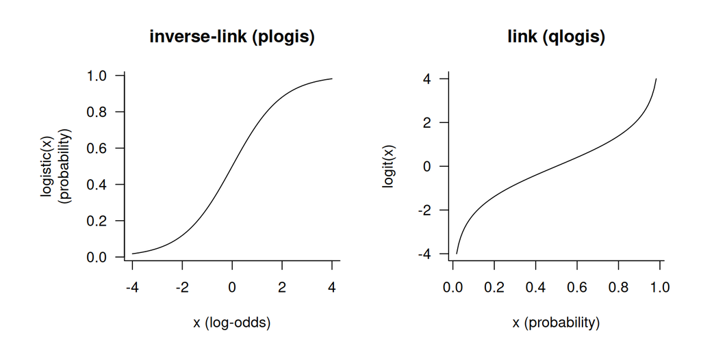

## diagnostics

- harder than linear models: `plot` is still somewhat useful
- binary data especially hard
- goodness of fit tests, \(R^2\) etc. hard (can always compute `cor(observed,predict(model, type="response"))`)
- residuals are *Pearson residuals* by default [`(obs-exp)/sqrt(V(exp))`]
- predicted values on the linear predictor scale by default: use `type="response"` to back-transform
- `performance::check_model()`, `DHARMa` package are OK (`simulateResiduals(model,plot=TRUE)`)

## overdispersion

- too much variance: (residual deviance)/(residual df) should be \(\approx 1\). (Ratio >1.2 worrisome; ratio>3, v. worrisome (check your model & data!)
- **quasi-likelihood models** (e.g. `family=quasipoisson`); fit, then adjust CIs/p-values
- alternatives:
  - Poisson \(\to\) negative binomial (`MASS::glm.nb`, `glmmTMB`)
  - binomial \(\to\) beta-binomial (`glmmTMB`)
- overdispersion **not relevant** for
  - binary responses
  - families/models that estimate dispersion (Gaussian, Gamma, neg binom, …)

## Parameter interpretation

- as with linear models (change in response per change in input)
- but on *linear predictor* scale
- log link: proportional for small \(\beta\)
  - e.g. \(\beta=0.01 \to\) “\(\approx\) 1% change per unit change in input”
  - \(\beta=3 \to\) “\((e^3) \approx\) 20-fold change per change in input”

## logit link

- log odds
- odds = \(p/(1-p)\) (1% probability is 1:99; 50% = 1:1)
- effect of 1 unit change = **multiply** by **odds ratio** (neutral=1)
- … or add **log-odds** = logit (neutral: `qlogis(0.5)` == 0)

```r
qlogis(0.01)
```

```
## [1] -4.59512
```

```r
qlogis(0.99)
```

```
## [1] 4.59512
```

## interpreting logit scale

- effect on the prob scale **depends on baseline probability**
  - low baseline prob: like log link
  - high baseline prob: prop. change in (1-prob)
  - medium prob: absolute change \(\approx \beta/4\)
  - e.g. going from log-odds of 0 to 1; estimated \(\Delta\) prob \(\approx\) 0.25
    - `plogis(0)=` 0.5
    - `plogis(0+1)=` 0.73
- also see [UCLA FAQ on odds ratios](https://stats.idre.ucla.edu/other/mult-pkg/faq/general/faq-how-do-i-interpret-odds-ratios-in-logistic-regression/); Gelman and Hill (2006) (p. 82; [Google books link](https://books.google.ca/books?id=lV3DIdV0F9AC&printsec=frontcover&dq=gelman+hill+logistic+parameter&hl=en&sa=X&ved=0ahUKEwjt8Zq_1-bgAhUqzIMKHTl0D3EQ6AEIKjAA#v=snippet&q=divide%20by%204&f=false))

## inference

- Wald \(Z\) tests (i.e., results of `summary()`),
  - **approximate**: may be way off if parameters have extreme values (*complete separation*)
  - \(Z\) rather than \(t\) tests: “degrees of freedom” usually ignored
- likelihood ratio tests (equivalent to \(F\) tests); `drop1(model,test="Chisq")`, `anova(model1,model2)`), profile confidence intervals (`MASS::confint.glm`)
  - A little bit harder, but generally preferred
- AIC etc.

## Model procedures

- formula like `lm`
- specify family (variance-mean), link (nonlinearity)
- always do Poisson, binomial regression on *counts*, never proportions (although can specify response as a proportion if you also give \(N\) as the `weights` argument)
  - Use *offsets* to address unequal sampling
- **always check for overdispersion** if necessary (Poisson/binomial \(N>1\))
- if you want to quote values on the original scale, confidence intervals need to be back-transformed; *never back-transform standard errors alone*

## binomial models

- for Poisson, Bernoulli (0/1) responses we only need one piece of information
- how do we specify denominator (\(N\) in \(k/N\))?
- traditional R: response is two-column matrix `cbind(successes,failures)` [**not** `cbind(successes,total)`]
- also allowed: response is proportion (\(k/N\)), also specify `weights=N`  
  (if equal for all cases and specified on the fly need to replicate:  
  `glm(p~...,data,weights=rep(N,nrow(data)))`)

## offsets

- constant terms added to a model
- e.g. what if we want to model densities rather than counts?
- log-link (Poisson/NB) models: \(\mu_0 = \exp(\beta_0 + \beta_1 x_1 + ...)\)
- if we know the area then we want \(\mu = A \cdot \mu_0\)
- equivalent to adding \(\log(A)\) to the linear predictor (\(\exp(\log(\mu_0) + \log(A)) = \mu_0 \cdot A\))
- use `... + offset(log(A))` in R formula
- for survival/event modeling over different periods of time, a similar offset trick works with `link="cloglog"` (see [here](https://stats.stackexchange.com/questions/148699/modelling-a-binary-outcome-when-census-interval-varies))

## add-on packages

- `ggplot2`
  - `geom_smooth(method="glm", method.args=list(family=...))`
- `dotwhisker`, `emmeans`, `effects`, `sjPlot`, `marginaleffects`
  - need to interpret parameters appropriately
  - means may be computed on linear predictor *or* response scale

## Advanced topics

- complete separation
- ordinal data
- zero-inflation
- non-standard link functions
- visualization (hard because of overlaps: try `stat_sum`, `position="jitter"`, `geom_dotplot`, ([beeswarm plot](http://stackoverflow.com/questions/11889353/avoiding-overlap-when-jittering-points%20beeswarm%20plot%5D))
- see also: GLM extensions talk ([source](https://github.com/bbolker/iiscvisit/blob/master/workshops/glm_extensions.rmd))

## Common `glm()` problems

- ignoring overdispersion
- binomial or Poisson models with non-integer responses (use offsets?)
- leaving out `family=` in `glm()`
- forgetting `predict()` uses linear predictor scale by default
- worrying about overdispersion when you don’t have to
- using `offset(A)` rather than `offset(log(A))`
- ignoring random effects (next topic – mixed models)

## Example

## AIDS in Australia (Dobson and Barnett 2008)

data here

```r
aids <- read.csv("../data/aids.csv")
aids <- transform(aids, date=year+(quarter-1)/4)
gg0 <- ggplot(aids,aes(date,cases))+geom_point()
```

## Easy GLMs with ggplot

```r
gg1 <- gg0 + geom_smooth(method="glm",colour="red",
                         formula=y~x,
                         method.args=list(family="quasipoisson"))
```

## results

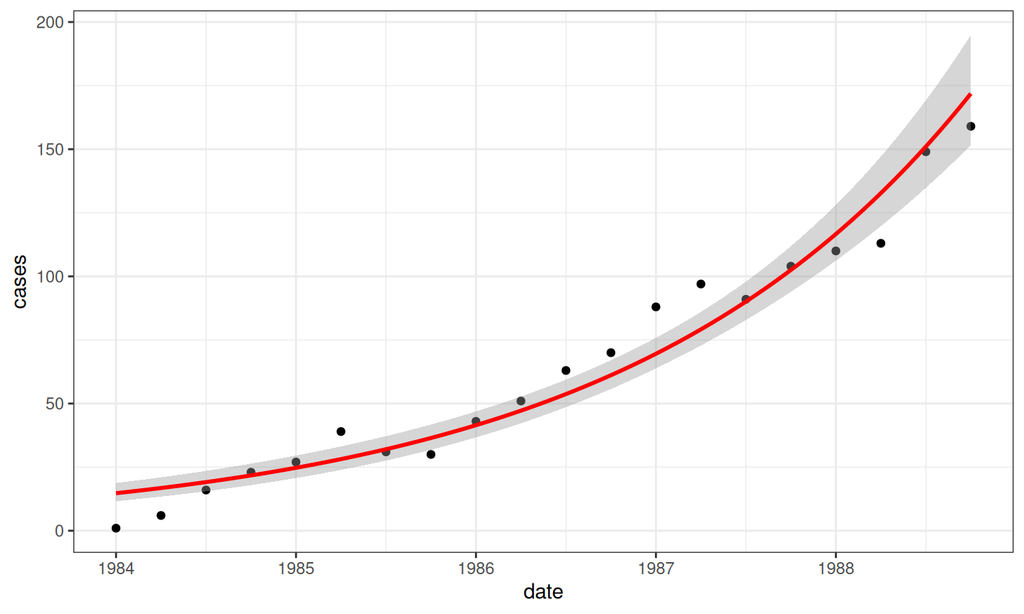

## Equivalent code

```r
g1 <- glm(cases~date, data = aids, family=quasipoisson(link="log"))
summary(g1)
```

[output not shown]

## Diagnostics (`plot(g1)`)

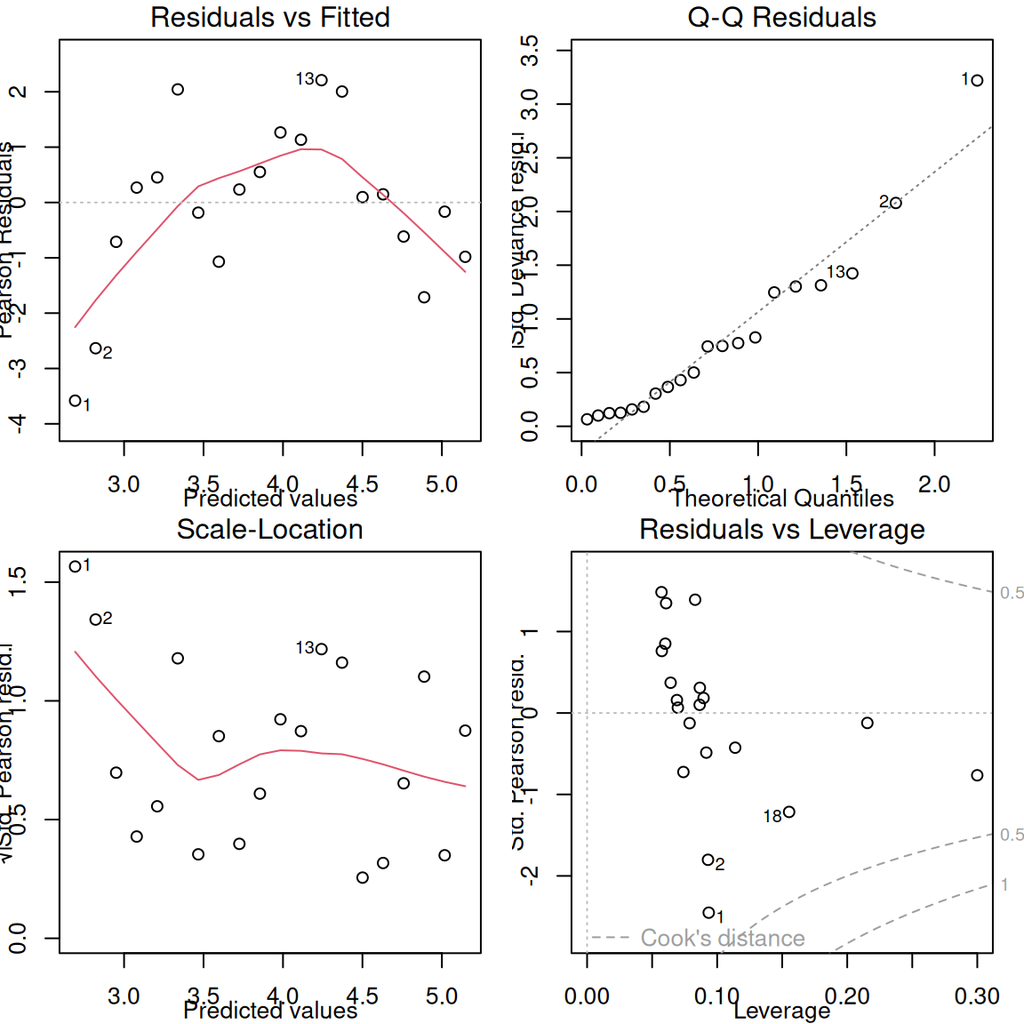

## performance

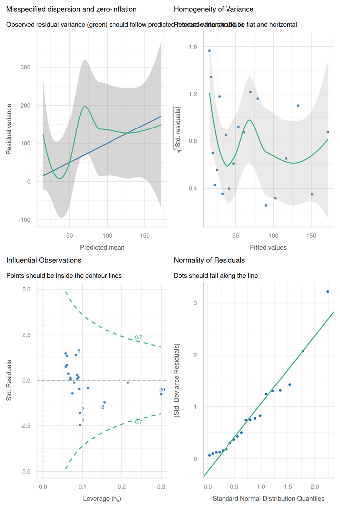

```r
performance::check_model(g1)
```

## DHARMa

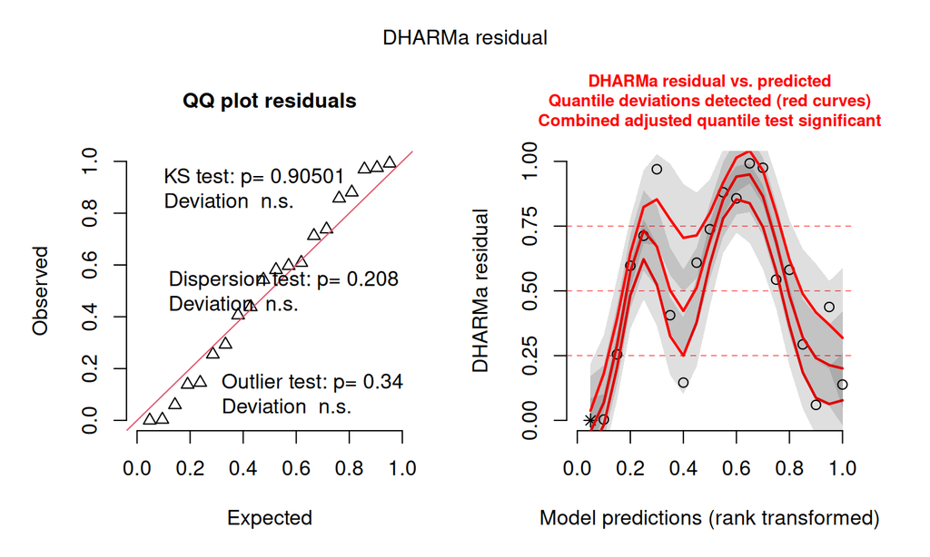

```r
library(DHARMa)
g0 <- update(g1, family=poisson)
plot(simulateResiduals(g0))
```

## ggplot: try quadratic model

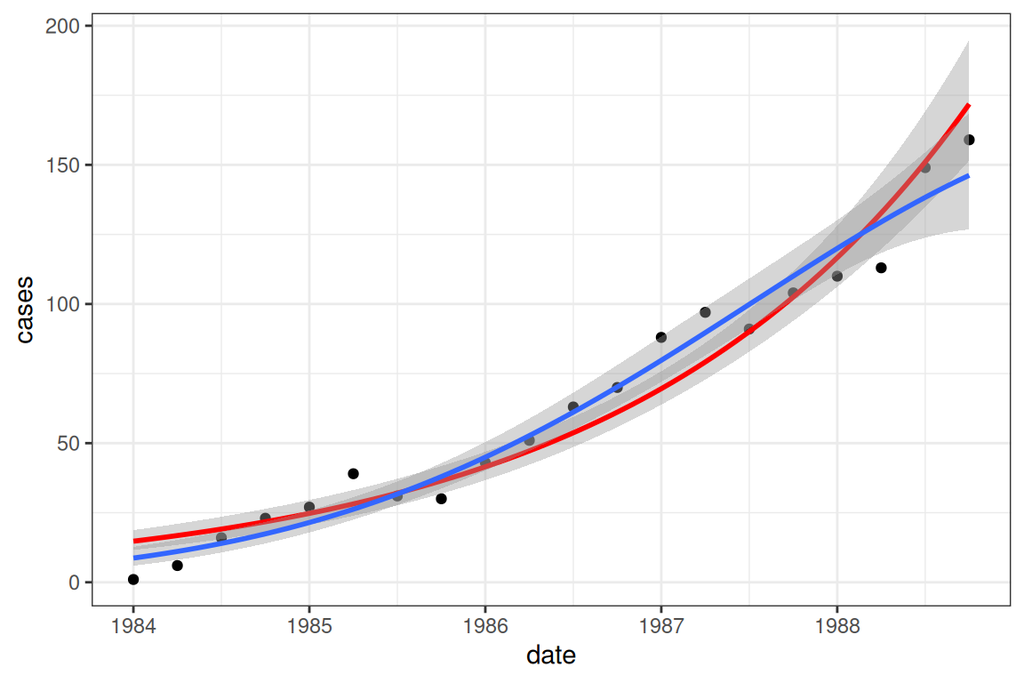

```r
print(gg2 <- gg1+geom_smooth(method="glm",formula=y~poly(x,2),
                             method.args=list(family="quasipoisson")))
```

(see [here](https://stackoverflow.com/a/30000214/190277), [here](https://stackoverflow.com/a/31473582/190277) for information on `poly()`)

## improved model

```r
g2 <- update(g1, . ~ poly(date,2))
```

## new diagnostics

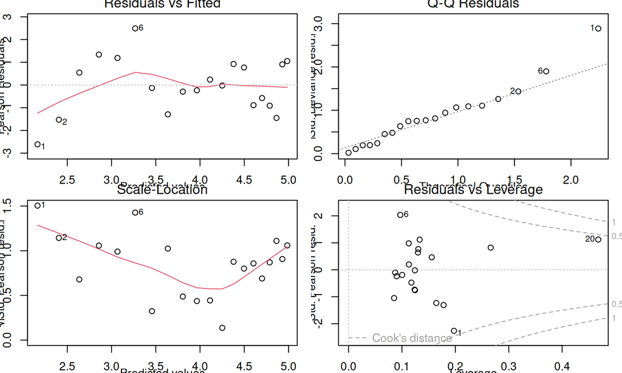

## inference

```r
g3 <- update(g2, data = transform(aids, date = date - min(date)))
summary(g3)
```

```
##
## Call:
## glm(formula = cases ~ poly(date, 2), family = quasipoisson(link = "log"),
##     data = transform(aids, date = date - min(date)))
##
## Coefficients:
##                Estimate Std. Error t value Pr(>|t|)
## (Intercept)     3.86859    0.05004  77.311  < 2e-16 ***
## poly(date, 2)1  3.82934    0.25162  15.219 2.46e-11 ***
## poly(date, 2)2 -0.68335    0.19716  -3.466  0.00295 **
## ---
## Signif. codes:  0 '***' 0.001 '**' 0.01 '*' 0.05 '.' 0.1 ' ' 1
##
## (Dispersion parameter for quasipoisson family taken to be 1.657309)
##
##     Null deviance: 677.264  on 19  degrees of freedom
## Residual deviance:  31.992  on 17  degrees of freedom
## AIC: NA
##
## Number of Fisher Scoring iterations: 4
```

```r
anova(g1,g2,test="F") ## for quasi-models specifically
```

```
## Analysis of Deviance Table
##
## Model 1: cases ~ date
## Model 2: cases ~ poly(date, 2)
##   Resid. Df Resid. Dev Df Deviance      F   Pr(>F)
## 1        18     53.020
## 2        17     31.992  1   21.028 12.688 0.002399 **
## ---
## Signif. codes:  0 '***' 0.001 '**' 0.01 '*' 0.05 '.' 0.1 ' ' 1
```

## References

Dobson, Annette J., and Adrian Barnett. 2008. *An Introduction to Generalized Linear Models*. 3rd ed. Chapman; Hall/CRC.

Gelman, Andrew, and Jennifer Hill. 2006. *Data Analysis Using Regression and Multilevel/ Hierarchical Models*. Cambridge, England: Cambridge University Press.